# p8105_hw5_sw3455

Shiying Wu

2024-11-13

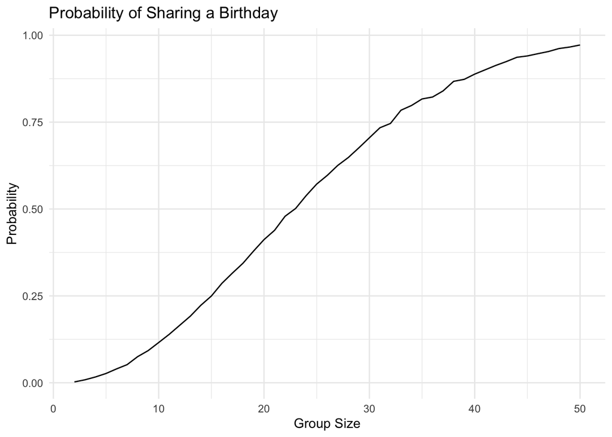

```r
birthday = function(n) {
  bdays = sample(1:365, size = n, replace = TRUE)
  duplicate = length(unique(bdays)) < n
  return(duplicate)
}

output <- vector("list", 49)

for (i in 2:50) {
  results <- 0
  for (j in 1:10000){
  if (birthday(i)) {results = results + 1}
  }
  output[[i - 1]] <- tibble(size = i, prob = results / 10000)
}

bind_rows(output)|>
  ggplot(aes(x = size, y = prob)) +
  geom_line() +
  labs(title = "Probability of Sharing a Birthday",
       x = "Group Size",
       y = "Probability") +
  theme_minimal()
```

As number of people increase, the probability also increases exponentially. Surprisingly when there’s 50 people in the room, the probability is almost 1.

```r
ttest = function(mu) {
  ttest_output <- vector("list", 5000)
  for (i in 1:5000) {
  data <- rnorm(30, mean = mu, sd = 5)
  table <- t.test(data, mu = 0)|>
    broom::tidy() |>
    select(estimate, p.value)
  ttest_output[[i]] <- tibble(mu = mu, table)
  }
  return(bind_rows(ttest_output))
}

ttest_output <- vector("list", 7)
for (i in 0:6) {
    ttest_output[[i+1]] <- ttest(i)}
ttest_result <- bind_rows(ttest_output)
```

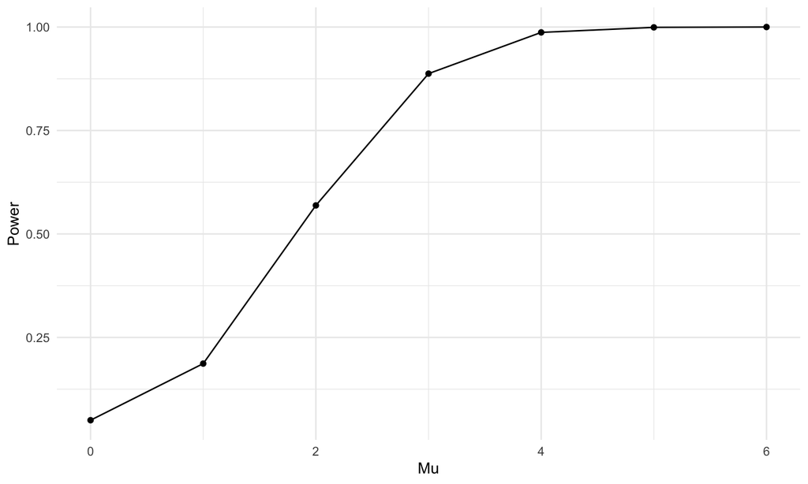

```r
ttest_result |>
  group_by(mu) |>
  summarise(power = mean(p.value < 0.05)) |>
  ggplot(aes(x = mu, y = power)) +
  geom_point() +
  geom_line() +
  labs(x = "Mu",
       y = "Power") +
  theme_minimal()
```

As the effect size increases (meaning the true mean mu be larger away from the null hypothesis mean 0), the power of the test increases(higher proportion of rejection) exponentialy. As true mean reach more than 4, the rejection more and more close to 1.

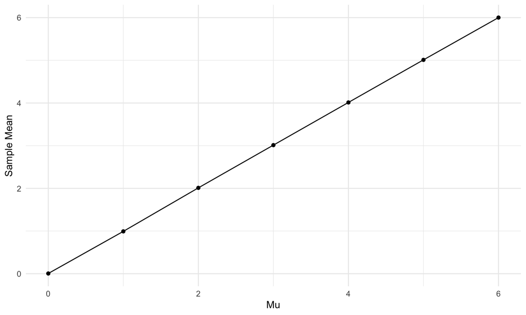

```r
ttest_result |>
  group_by(mu) |>
  summarise(Sample_Mean = mean(estimate)) |>
  ggplot(aes(x = mu, y = Sample_Mean)) +
  geom_point() +
  geom_line() +
  labs(x = "Mu",
       y = "Sample Mean") +
  theme_minimal()
```

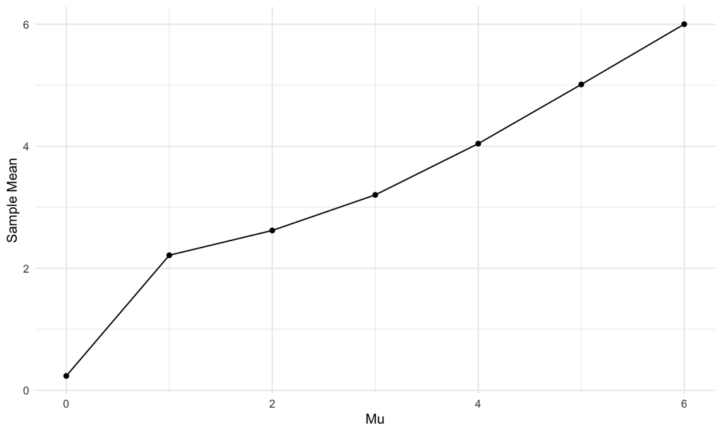

```r
ttest_result |>
  filter(p.value < 0.05) |>
  group_by(mu) |>
  summarise(Sample_Mean = mean(estimate)) |>
  ggplot(aes(x = mu, y = Sample_Mean)) +
  geom_point() +
  geom_line() +
  labs(x = "Mu",
       y = "Sample Mean") +
  theme_minimal()
```

On the plot 2, mean of each 5000 sample mean is really close to their true mean. Compare to plot 3 for the rejected sample it is significantly more or less then their true mean as line is not a straight line before 4, however, after 4, the sample mean are similar to their ture mean and similar line as plot 2.

```r
homicides = read.csv("./data/homicide-data.csv",
        na = c(".", "NA", "")) |>
  janitor::clean_names()
```

The data has have 12 columns which means have 12 variables and 52179 rows means 52179 criminal homicides. The 12 variables are uid, reported_date, victim_last, victim_first, victim_race, victim_age, victim_sex, city, state, lat, lon, disposition. It including date and location for the homicides, geograophic imformation about victim and situation of homicides whether it is closed or still open.

```r
homicide_df <- homicides |>
  mutate(city_state = paste(city, state, sep = ", ")) |>
  filter(city_state != "Tulsa, AL") |>
  group_by(city_state) |>
  summarise(
    total_homicides = n(),
    unsolved_homicides = sum(disposition %in% c("Closed without arrest", "Open/No arrest"))
  )
```

There is only one cases in Tulsa, AL, and after googling, there is no Tulsa city in AL which count as a mistake

```r
proptest = function(unsolved_homicides, total_homicides) {
  prop_test = prop.test(unsolved_homicides, total_homicides) |>
  broom::tidy(prop_test) |>
  select(estimate, conf.low, conf.high)
  return(tibble(prop_test))
}

Baltimore_df <- homicide_df |>
  filter(city_state == "Baltimore, MD")

Baltimore_result <-
  proptest(Baltimore_df$unsolved_homicides, Baltimore_df$total_homicides)
```

```r
overall_results =
  homicide_df |>
  mutate(results = purrr::map2(unsolved_homicides, total_homicides, proptest)) |>
  unnest(results)|>
  select(city_state, estimate, conf.low, conf.high)
```

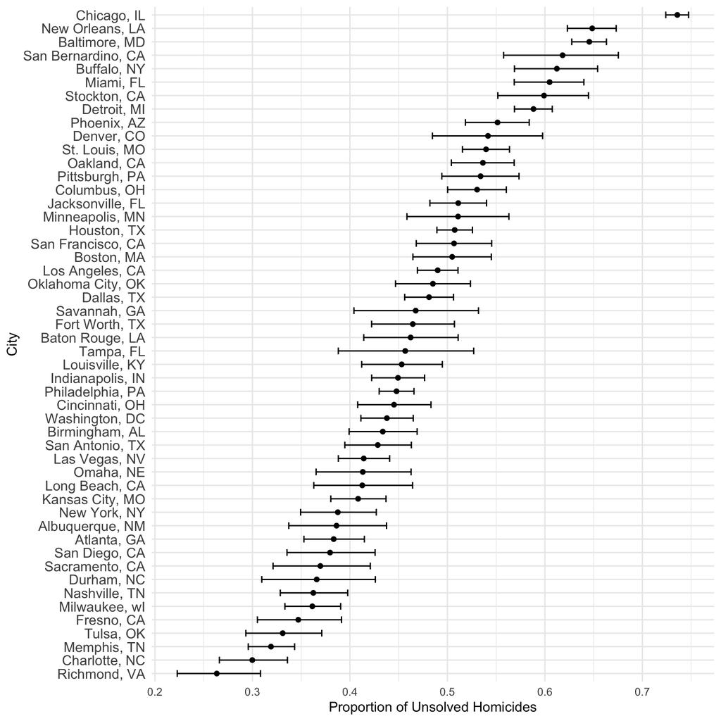

```r
overall_results|>
  arrange(desc(estimate))|>
  ggplot(aes(x = fct_reorder(city_state, estimate), y = estimate)) +
  geom_point() +
  geom_errorbar(aes(ymin = conf.low, ymax = conf.high), width = 0.5) +
  coord_flip() +
  labs(x = "City",
       y = "Proportion of Unsolved Homicides") +
  theme_minimal() +
  theme(axis.text.y = element_text(size = 11))
```